# US Flights in 2008 and comparisons with other years

#### `Airline` and `LateAircraftDelay`

**Are there certain airlines where more delays occur due to late aircraft arrival?**

As an extension to the previous analysis on `CarrierDelay`, this takes a look at late aircraft delay.

```python
# Calculates the average time delayed due to late aircraft arrival
late_delay = f2008_clean.groupby("Airline").LateAircraftDelay.sum()
airline_count = f2008_clean.groupby("Airline").count()["Year"]
late_delay_prop = (late_delay/airline_count).sort_values(ascending = False)
```

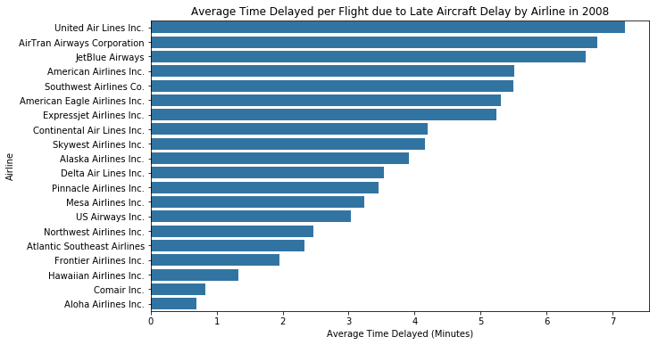

```python
plt.figure(figsize = (10, 6))
sb.barplot(y = late_delay_prop.index, x = late_delay_prop.values, color = base_color)
plt.title("Average Time Delayed per Flight due to Late Aircraft Delay by Airline in 2008")
plt.xlabel("Average Time Delayed (Minutes)");
```

For Late Aircraft Delay, United Air Lines Inc. has the highest average time delayed per flight. Aloha Airlines Inc., again, has the lowest average delayed time.

#### `Origin_city` and `WeatherDelay`

Are there certain departure cities where more delays occur due to the weather?

```python
# Groupby city and find the total number of flights delayed due to weather, and the total time of delay, and the average time delayed
weather_delay_origin_count = f2008_clean.groupby("Origin_city").WeatherDelay.count().sort_values(ascending = False)
weather_delay_origin_total = f2008_clean.groupby("Origin_city").WeatherDelay.sum().sort_values(ascending = False)
```

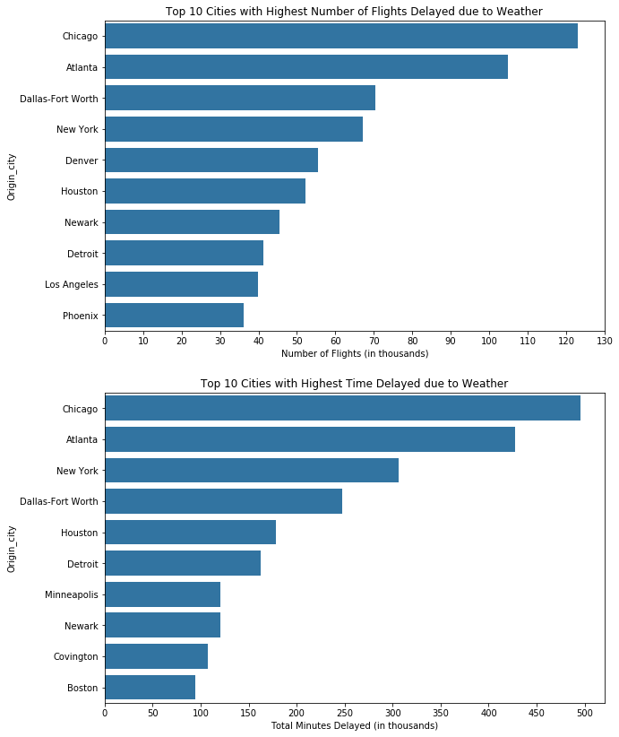

```python
plt.figure(figsize = (10, 14))

plt.subplot(3, 1, 1)
sb.barplot(y = weather_delay_origin_count.index[0:10], x = weather_delay_origin_count.values[0:10],
           color = base_color)
plt.title("Top 10 Cities with Highest Number of Flights Delayed due to Weather")
plt.xlabel("Number of Flights (in thousands)")
ticks18 = np.array([n for n in range(0, 140, 10)])
plt.xticks(ticks18*1000, ticks18);

plt.subplot(3, 1, 2)
sb.barplot(y = weather_delay_origin_total.index[0:10], x = weather_delay_origin_total.values[0:10],
           color = base_color)
plt.title("Top 10 Cities with Highest Time Delayed due to Weather")
plt.xlabel("Total Minutes Delayed (in thousands)")
ticks19 = np.array([n for n in range(0, 501, 50)])
plt.xticks(ticks19*1000, ticks19);
```

Chicago, Atlanta, Dallas-Fort Worth, New York, Housten, Newark, and Detroit is in the top 10 cities with the highest number of flights delayed and total cumulative time delayed in 2008.

### Analysis and Insights of Bivariate Exploration

The following interesting insights have been found:

- **`Cancelled` by `Month`**
  - The proportion of flights cancelled in 2008 is highest in February, December and January (in that order), and lowest in October and November.
  - Could the highest proportion of cancellations between December-February be due to the cold and bad weather?
- **`CancellationReason` by `Month`**
  - This provides further insights on the potential reasons why December-February have the highest proportions of cancellations. The main reason for cancellations is indeed due to bad weather for December and February. January has a fairly similar number of cancellations due to weather and carrier, with both numbers still high.
  - Overall, there are very very few cancellations due to security reasons.
- **`ActualElapsedTime` and `CRSElapsedTime`**
  - The distribution of both actual and scheduled elapsed time are very similar, with a weak positive (right) skew, peaking between 70 and 90 minutes.
  - This is expected as once the aircraft is taking off, the difference between actual and scheduled elapsed times should be close to zero.
- **`DepDelay` and `ArrDelay`**
  - The median for both departure and arrival delays are fairly similar at -1 and -2 minutes, respectively.
  - The interquartile range IQR is larger for arrival delays (22 minutes) than departure delays (12 minutes).
  - The arrival delay is computed from the difference between actual and scheduled arrival time, where the former has some uncertainty itself (aircrafts may arrive earlier or later depending on many conditions, such as direction of wind, busyness of airport, etc.). This could lead to a larger uncertainty in the arrival delay, compared with departure delay, and therefore we see a larger IQR.
- **`AirTime` and `Distance`**
  - They have a strong positive correlation, i.e. the further the distance between the origin and destination, the greater the time in air.
  - There are outliers lying in a thin vertical line at a distance between 2677 and 2762 miles. These outliers are all the routes between a Hawaiian airport and Las Vegas or Seattle. Seven of the 9 flights leave roughly on time but arrive at the destination a lot later. The arrival delay are all due to carrier delay, although it is not clear what happens to the aircraft during this carrier delay as the aircraft appears to be in air. The other two flights depart significantly later (over three hours) but still has a carrier delay. These flights appear to be outliers.
- **`Distance` and `Airline`**
  - Many airlines operate flights under 2000 miles, including Southwest Airlines Co., Expressjet Airlines Inc., Mesa Airlines Inc., Comair Inc., Skywest Airlines Inc., Atlantic Southeast Airlines, American Eagle Airlines Inc., and Pinnacle Airlines Inc.
  - Both Hawaiian Airlines Inc. and Aloha Airlines Inc. have a pronounced bimodal peaks. The peaks at short distances correspond to flights between Hawaiian airports (e.g. Honolulu, Kahului, Lihue), and the peaks at distances above 2000 miles are flights to Californian cities (e.g. Santa Ana, Oakland, Sacramento). This is expected as Hawaii is an island far off the coast of the US, and either airlines will fly to another Hawaiian city or to mainland - thus showing the bimodal relationship.
  - Several airlines operate many different routes at different distances shown by the multimodal peaks, such as United Air Lines Inc., Delta Air Lines Inc., American Airlines Inc., Alaska Airlines Inc., JetBlue Airways, and Continental Air Lines Inc.
- **`Airline` and `CarrierDelay`**
  - From this barchart, it can be shown that Mesa Airlines Inc. has the highest average time delayed per flight due to carrier delay, over 1.5 minutes higher on average compared with the second highest: Atlantic Southeast Airlines.
  - Aloha Airlines Inc. has the lowest average time delayed.
- **`Airline` and `LateAircraftDelay`**
  - United Air Lines Inc. has the highest average time delayed per flight.
  - Aloha Airlines Inc., again, has the lowest average delayed time. Aloha Airlines Inc. operate fewest flights - could it be that a smaller volume of flights may lead to more efficiency?
- **`Origin_city` and `WeatherDelay`**
  - Chicago, Atlanta, Dallas-Fort Worth, New York, Housten, Newark, and Detroit is in the top 10 cities with the highest number of flights delayed and total cumulative time delayed in 2008.

Jump to Bivariate Visualisations

## Multivariate Exploration

In multivariate exploration, plots of three or more variables are investigated and analysed. In this section the 2008 flights are explored.

1. `Month`, `Cancelled`, and `CancellationReason` - given all cancelled flights, what are the proportions of different cancellation reasons grouped by month?
2. `Origin_city` and `Dest_city` - are there certain routes that are particularly popular for flights?
3. `CarrierDelay` and `LateAircraftDelay` by `Airline` - which airlines have the best and worst delay record (due to airline's own responsibility)?
4. `ArrDelay`, `DepDelay`, and `Year` - how has the average departure and arrival delay change over the past 20 years (five year intervals between 1988-2008)?
5. Number of flights throughout the `Year` - how has the number of flight departures for every day change over the past 20 years (five year intervals between 1988-2008)?

Jump to Multivariate Insights and Interpretations

#### `Month`, `Cancelled`, and `CancellationReason`

**Given all cancelled flights, what are the proportions of different cancellation reasons grouped by month?**

To address this question, a stacked bar chart will be plotted. Firstly, the total number of cancelled flights will be plotted by month, colour coded by the reasons of cancellations.

```python
# This computes the number of cancellations by month for each reason
cancellation_month = f2008_clean.groupby(["Month"]).CancellationReason.value_counts()
cancellation_month.head(10)
```

```
Month  CancellationReason
1      weather                6711
       carrier                6635
       NAS                    3962
2      weather               10034
       carrier                6090
       NAS                    4470
       security                  2
3      weather                7520
       carrier                6038
       NAS                    2621
Name: CancellationReason, dtype: int64
```

```python
cancellation_tot_df = pd.DataFrame(cancellation_month).unstack("CancellationReason")
cancellation_tot_df.head()
```

| CancellationReason Month | CancellationReason NAS | CancellationReason carrier | CancellationReason security | CancellationReason weather |
| --- | --- | --- | --- | --- |
| 1 | 3962.0 | 6635.0 | NaN | 6711.0 |
| 2 | 4470.0 | 6090.0 | 2.0 | 10034.0 |
| 3 | 2621.0 | 6038.0 | 4.0 | 7520.0 |
| 4 | 1564.0 | 7312.0 | NaN | 1479.0 |
| 5 | 1608.0 | 3157.0 | 3.0 | 1461.0 |

```python
# Convert each cancellation reasons to numpy array for ease of plotting
carrier_tot = np.array(cancellation_tot_df.CancellationReason.carrier)
weather_tot = np.array(cancellation_tot_df.CancellationReason.weather)
nas_tot = np.array(cancellation_tot_df.CancellationReason.NAS)
security_tot = np.array(cancellation_tot_df.CancellationReason.security.fillna(0))
nas_tot
```

```
array([3962., 4470., 2621., 1564., 1608., 3232., 2694., 2401., 1188.,
        552., 1009., 2887.])
```

```python
# x locations by month
months = cancellation_tot_df.index
months
```

```
Int64Index([1, 2, 3, 4, 5, 6, 7, 8, 9, 10, 11, 12], dtype='int64', name='Month')
```

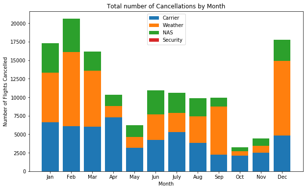

```python
plt.figure(figsize = (10, 6))

# Plotting stacked barchart. Parameter "bottom" gives the location to start plotting
tot1 = plt.bar(months, carrier_tot)
tot2 = plt.bar(months, weather_tot, bottom = carrier_tot)
tot3 = plt.bar(months, nas_tot, bottom = carrier_tot + weather_tot)
tot4 = plt.bar(months, security_tot, bottom = carrier_tot + weather_tot + nas_tot)

plt.title("Total number of Cancellations by Month")
plt.ylabel("Number of Flights Cancelled")
plt.xlabel("Month")
plt.legend((tot1, tot2, tot3, tot4), ("Carrier", "Weather", "NAS", "Security"), loc = "upper center")
plt.xticks(months, months.map(months_dict));
```

```python
# total number of flights cancelled due to security reasons by month
security_tot.astype(int), sum(cancellation_month)
```

```
(array([0, 2, 4, 0, 3, 0, 0, 0, 1, 0, 2, 0]), 137434)
```

Both weather and carrier are the main causes for cancellations. In February, September, and December, the large proportion of flights were cancelled due to weather.

The following plot looks at the proportion of flights cancelled due to different reasons.

```python
# denominator computes total number of cancellations by month
# result computes the proportion of cancellations
total_cancellation_month = f2008_clean.groupby(["Month"]).CancellationReason.count()
cancellation_prop = cancellation_month/total_cancellation_month
cancellation_prop.head()
```

```
Month  CancellationReason
1      weather               0.387740
       carrier               0.383349
       NAS                   0.228911
2      weather               0.487182
       carrier               0.295688
Name: CancellationReason, dtype: float64
```

```python
# Unstack to simplify structure for plotting
cancellation_prop_df = pd.DataFrame(cancellation_prop).unstack("CancellationReason")
cancellation_prop_df.head()
```

| CancellationReason Month | CancellationReason NAS | CancellationReason carrier | CancellationReason security | CancellationReason weather |
| --- | --- | --- | --- | --- |
| 1 | 0.228911 | 0.383349 | NaN | 0.387740 |
| 2 | 0.217032 | 0.295688 | 0.000097 | 0.487182 |
| 3 | 0.161960 | 0.373108 | 0.000247 | 0.464685 |
| 4 | 0.151038 | 0.706132 | NaN | 0.142830 |
| 5 | 0.258147 | 0.506823 | 0.000482 | 0.234548 |

```python
# Convert each cancellation reasons to numpy array for ease of plotting
carrier_prop = np.array(cancellation_prop_df.CancellationReason.carrier)
weather_prop = np.array(cancellation_prop_df.CancellationReason.weather)
nas_prop = np.array(cancellation_prop_df.CancellationReason.NAS)
security_prop = np.array(cancellation_prop_df.CancellationReason.security.fillna(0))
nas_prop
```

```
array([0.22891149, 0.21703243, 0.16196008, 0.15103815, 0.25814738,
       0.29567286, 0.25419891, 0.24412811, 0.11984263, 0.16989843,
       0.22633468, 0.16238259])
```

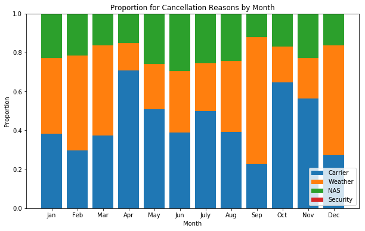

```python
plt.figure(figsize = (10, 6))

# Plotting stacked barchart. Parameter "bottom" gives the location to start plotting
p1 = plt.bar(months, carrier_prop)
p2 = plt.bar(months, weather_prop, bottom = carrier_prop)
p3 = plt.bar(months, nas_prop, bottom = carrier_prop + weather_prop)
p4 = plt.bar(months, security_prop, bottom = carrier_prop + weather_prop + nas_prop)

plt.title("Proportion for Cancellation Reasons by Month")
plt.ylabel("Proportion")
plt.xlabel("Month")
plt.xticks(months, months.map(months_dict))
plt.legend((p1, p2, p3, p4), ("Carrier", "Weather", "NAS", "Security"), loc = 4);
```

This figure shows more pronounced the proportions between the different reasons for cancellations. Cancellations due to carrier is highest in April, May, June, July, August, October and November. Cancellations due to weather is highest in February, March, September, and December. In January, the proportions of carrier and weather cancellations are roughly equal. NAS cancellations take up around 10-30% of all cancellations for each given month. Security cancellations are very rare.

#### `Origin_city` and `Dest_city`

**Are there certain routes that are particularly popular for flights?**

```python
routes = f2008_clean[["Origin_city", "Dest_city"]]
routes["Route"] = routes["Origin_city"] + " - "+ routes["Dest_city"]
routes.head()
```

|  | Origin_city | Dest_city | Route |
| --- | --- | --- | --- |
| 0 | Chantilly | Tampa | Chantilly - Tampa |
| 1 | Chantilly | Tampa | Chantilly - Tampa |
| 2 | Indianapolis | Baltimore | Indianapolis - Baltimore |
| 3 | Indianapolis | Baltimore | Indianapolis - Baltimore |
| 4 | Indianapolis | Baltimore | Indianapolis - Baltimore |

```python
# Top 30 routes in 2008
routes.Route.value_counts()[0:30]
```

```
New York - Boston              19548
Boston - New York              19401
New York - Chicago             14534
Chicago - New York             14454
Arlington - New York           14119
New York - Arlington           14004
San Francisco - Los Angeles    13788
Dallas - Houston               13520
Houston - Dallas               13496
Los Angeles - San Francisco    13390
New York - Atlanta             12786
Atlanta - New York             12421
Kahului - Honolulu             12383
Honolulu - Kahului             12014
Los Angeles - Las Vegas        11773
Las Vegas - Los Angeles        11729
Los Angeles - San Diego        11257
San Diego - Los Angeles        11224
Chicago - Minneapolis          11164
Atlanta - Chicago              10933
Honolulu - Lihue               10769
Detroit - Chicago              10732
Minneapolis - Chicago          10723
Chicago - Atlanta              10706
Chicago - Detroit              10672
Las Vegas - Phoenix            10626
Lihue - Honolulu               10407
Denver - Chicago               10389
Phoenix - Las Vegas            10337
Chicago - Denver               10098
Name: Route, dtype: int64
```

Among the top 20 cities with the highest number of flight departures, what is the heatmap representing the number of flights between each cities? A heatmap is usually used for correlation. However, comparing the routes between 20 cities is a 20x20 = 400 data points, so a heatmap can be used to represent total volume of flights well.

```python
# routes contains counts of each route
# top20_origin contains the top 20 cities with highest number of depature flights
routes = f2008_clean.groupby(["Origin_city", "Dest_city"]).size()
routes = routes.reset_index(name = "count")
top20_origin = f2008_clean.Origin_city.value_counts()[0:20]
top20_origin
```

```
Chicago              437999
Atlanta              414513
Dallas-Fort Worth    281281
Denver               241443
Houston              241105
New York             237939
Los Angeles          215608
Phoenix              199408
Las Vegas            172876
Detroit              161989
San Francisco        140587
Salt Lake City       139088
Newark               138506
Orlando              130872
Minneapolis          130289
Charlotte            126045
Boston               117915
Seattle              109069
Baltimore            104074
Philadelphia         100499
Name: Origin_city, dtype: int64
```

```python
# Mask to give only the routes that contain departure and destination cities in the top 20
top20_cities = routes[routes.Origin_city.isin(top20_origin.index) & routes.Dest_city.isin(top20_origin.index)]
top20_cities.head()
```

|  | Origin_city | Dest_city | count |
| --- | --- | --- | --- |
| 214 | Atlanta | Baltimore | 5978 |
| 220 | Atlanta | Boston | 5990 |
| 229 | Atlanta | Charlotte | 6720 |
| 233 | Atlanta | Chicago | 10933 |
| 242 | Atlanta | Dallas-Fort Worth | 9847 |

```python
top20_cities = top20_cities.pivot(index = "Origin_city", columns = "Dest_city", values = "count")
top20_cities.head()
```

| Dest_city Origin_city | Atlanta | Baltimore | Boston | Charlotte | Chicago | Dallas-Fort Worth | Denver | Detroit | Houston | Las Vegas | Los Angeles | Minneapolis | New York | Newark | Orlando | Philadelphia | Phoenix | Salt Lake City | San Francisco | Seattle |
| --- | --- | --- | --- | --- | --- | --- | --- | --- | --- | --- | --- | --- | --- | --- | --- | --- | --- | --- | --- | --- |
| Atlanta | NaN | 5978.0 | 5990.0 | 6720.0 | 10933.0 | 9847.0 | 5726.0 | 5612.0 | 8861.0 | 4766.0 | 5406.0 | 5368.0 | 12421.0 | 8028.0 | 9613.0 | 6915.0 | 4603.0 | 2860.0 | 3462.0 | 2574.0 |
| Baltimore | 5972.0 | NaN | 4795.0 | 3652.0 | 6354.0 | 2311.0 | 2664.0 | 3105.0 | 2990.0 | 1626.0 | 898.0 | 974.0 | 1141.0 | 507.0 | 4926.0 | 692.0 | 2098.0 | 727.0 | 366.0 | 242.0 |
| Boston | 5982.0 | 4797.0 | NaN | 3533.0 | 7429.0 | 3036.0 | 2077.0 | 2306.0 | 1800.0 | 1383.0 | 2234.0 | 1635.0 | 19401.0 | 3883.0 | 3474.0 | 6375.0 | 1069.0 | 707.0 | 2668.0 | 979.0 |
| Charlotte | 6722.0 | 3684.0 | 3551.0 | NaN | 5652.0 | 3796.0 | 1925.0 | 2701.0 | 3711.0 | 1734.0 | 1458.0 | 1816.0 | 7205.0 | 5953.0 | 3277.0 | 3525.0 | 2186.0 | 212.0 | 1427.0 | 481.0 |
| Chicago | 10706.0 | 6328.0 | 7478.0 | 6026.0 | NaN | 8093.0 | 10098.0 | 10672.0 | 7515.0 | 9089.0 | 9364.0 | 11164.0 | 14454.0 | 7452.0 | 7366.0 | 9397.0 | 7924.0 | 3863.0 | 6607.0 | 6133.0 |

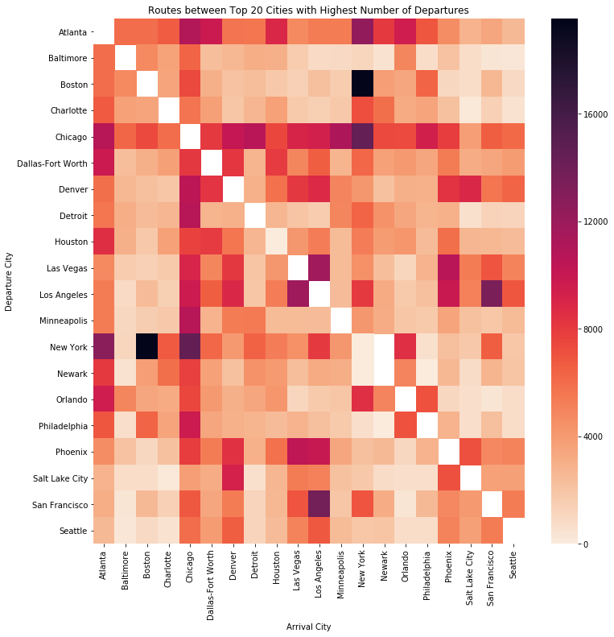

```python
plt.figure(figsize = (12, 12))
sb.heatmap(top20_cities, cmap = sb.cm.rocket_r)
plt.title("Routes between Top 20 Cities with Highest Number of Departures")
plt.xlabel("Arrival City")
plt.ylabel("Departure City");
```

From the heatmap, flights connecting Boston and New York are most common. Other popular routes between New York and Atlanta, New York and Chicago, and Los Angeles and San Francisco.

It can also be seen that there is a generally darker band running across and down the heatmap, corresponding to departure and arrival city: Chicago. This suggest that Chicago is one of the most busy airport in terms of the number of flight depatures and arrivals.

Interestingly, there are non-zero flights between the two locations within the city of New York as well as Houston. This is indicated by a pale pink/orange colour instead of white. We will look closely at New York as an example.

```python
top20_cities["New York"]
```

```
Origin_city
Atlanta              12421.0
Baltimore             1141.0
Boston               19401.0
Charlotte             7205.0
Chicago              14454.0
Dallas-Fort Worth     6198.0
Denver                4135.0
Detroit               6348.0
Houston               5312.0
Las Vegas             4481.0
Los Angeles           8058.0
Minneapolis           4164.0
New York                 2.0
Newark                   1.0
Orlando               8527.0
Philadelphia           679.0
Phoenix               2256.0
Salt Lake City        1808.0
San Francisco         6971.0
Seattle               1852.0
Name: New York, dtype: float64
```

```python
# New York origins and destination
NewYork = f2008_clean[f2008_clean.Origin_city == "New York"]
NewYork[NewYork.Dest_city == "New York"]
```

|  | Year | Month | DayofMonth | DayOfWeek | DepTime | CRSDepTime | ArrTime | CRSArrTime | ActualElapsedTime | CRSElapsedTime | AirTime | ArrDelay | DepDelay | Distance | Cancelled | CancellationReason | Diverted | CarrierDelay | WeatherDelay | NASDelay | SecurityDelay | LateAircraftDelay | Airline | Origin_city | Origin_state | Dest_city | Dest_state |
| --- | --- | --- | --- | --- | --- | --- | --- | --- | --- | --- | --- | --- | --- | --- | --- | --- | --- | --- | --- | --- | --- | --- | --- | --- | --- | --- | --- |
| 2547298 | 2008 | 5 | 15 | 4 | 2037 | 1800 | 2125 | 1900 | 48.0 | 60.0 | 31.0 | 145.0 | 157.0 | 11 | False | NaN | False | 145.0 | 0.0 | 0.0 | 0.0 | 0.0 | Comair Inc. | New York | NY | New York | NY |
| 4392215 | 2008 | 8 | 10 | 7 | 1315 | 1220 | 1415 | 1320 | 60.0 | 60.0 | 14.0 | 55.0 | 55.0 | 11 | False | NaN | False | 55.0 | 0.0 | 0.0 | 0.0 | 0.0 | Comair Inc. | New York | NY | New York | NY |

```python
# As the names of cities are dropped before, make a new DF to keep this information
f2008_mod = pd.merge(f2008, airports_mod, left_on = "Origin", right_on = "iata", how = "left")
f2008_mod = pd.merge(f2008_mod, airports_mod, left_on = "Dest", right_on = "iata", how = "left")
f2008_mod.head()
```

|  | Year | Month | DayofMonth | DayOfWeek | DepTime | CRSDepTime | ArrTime | CRSArrTime | UniqueCarrier | FlightNum | TailNum | ActualElapsedTime | CRSElapsedTime | AirTime | ... | Cancelled | CancellationCode | Diverted | CarrierDelay | WeatherDelay | NASDelay | SecurityDelay | LateAircraftDelay | iata_x | city_x | state_x | iata_y | city_y | state_y |
| --- | --- | --- | --- | --- | --- | --- | --- | --- | --- | --- | --- | --- | --- | --- | --- | --- | --- | --- | --- | --- | --- | --- | --- | --- | --- | --- | --- | --- | --- |
| 0 | 2008 | 1 | 3 | 4 | 2003.0 | 1955 | 2211.0 | 2225 | WN | 335 | N712SW | 128.0 | 150.0 | 116.0 | ... | 0 | NaN | 0 | NaN | NaN | NaN | NaN | NaN | IAD | Chantilly | VA | TPA | Tampa | FL |
| 1 | 2008 | 1 | 3 | 4 | 754.0 | 735 | 1002.0 | 1000 | WN | 3231 | N772SW | 128.0 | 145.0 | 113.0 | ... | 0 | NaN | 0 | NaN | NaN | NaN | NaN | NaN | IAD | Chantilly | VA | TPA | Tampa | FL |
| 2 | 2008 | 1 | 3 | 4 | 628.0 | 620 | 804.0 | 750 | WN | 448 | N428WN | 96.0 | 90.0 | 76.0 | ... | 0 | NaN | 0 | NaN | NaN | NaN | NaN | NaN | IND | Indianapolis | IN | BWI | Baltimore | MD |
| 3 | 2008 | 1 | 3 | 4 | 926.0 | 930 | 1054.0 | 1100 | WN | 1746 | N612SW | 88.0 | 90.0 | 78.0 | ... | 0 | NaN | 0 | NaN | NaN | NaN | NaN | NaN | IND | Indianapolis | IN | BWI | Baltimore | MD |
| 4 | 2008 | 1 | 3 | 4 | 1829.0 | 1755 | 1959.0 | 1925 | WN | 3920 | N464WN | 90.0 | 90.0 | 77.0 | ... | 0 | NaN | 0 | 2.0 | 0.0 | 0.0 | 0.0 | 32.0 | IND | Indianapolis | IN | BWI | Baltimore | MD |

5 rows × 35 columns

```python
# New York depature and arrival flights - full information
f2008_mod[(f2008_mod.city_x == "New York") & (f2008_mod.city_y == "New York")]
```

|  | Year | Month | DayofMonth | DayOfWeek | DepTime | CRSDepTime | ArrTime | CRSArrTime | UniqueCarrier | FlightNum | TailNum | ActualElapsedTime | CRSElapsedTime | AirTime | ... | Cancelled | CancellationCode | Diverted | CarrierDelay | WeatherDelay | NASDelay | SecurityDelay | LateAircraftDelay | iata_x | city_x | state_x | iata_y | city_y | state_y |
| --- | --- | --- | --- | --- | --- | --- | --- | --- | --- | --- | --- | --- | --- | --- | --- | --- | --- | --- | --- | --- | --- | --- | --- | --- | --- | --- | --- | --- | --- |
| 2547298 | 2008 | 5 | 15 | 4 | 2037.0 | 1800 | 2125.0 | 1900 | OH | 4988 | N806CA | 48.0 | 60.0 | 31.0 | ... | 0 | NaN | 0 | 145.0 | 0.0 | 0.0 | 0.0 | 0.0 | JFK | New York | NY | LGA | New York | NY |
| 4392215 | 2008 | 8 | 10 | 7 | 1315.0 | 1220 | 1415.0 | 1320 | OH | 5572 | N819CA | 60.0 | 60.0 | 14.0 | ... | 0 | NaN | 0 | 55.0 | 0.0 | 0.0 | 0.0 | 0.0 | JFK | New York | NY | LGA | New York | NY |

2 rows × 35 columns

A closer analysis below reveals that two flights have both departure and arrival cities in New York. These flights depart from John F. Kennedy International Airport (IATA: JFK) and arrive at LaGuardia Airport (IATA: LGA), both from the city of New York.

#### `CarrierDelay` and `LateAircraftDelay` by `Airline`

**Which airlines have the best and worst delay record (due to airline's own responsibility) on average?**

```python
delay_airline = f2008_clean.groupby("Airline")[["CarrierDelay", "LateAircraftDelay"]].sum()
delay_airline["TotalDelay"] = delay_airline["CarrierDelay"] + delay_airline["LateAircraftDelay"]
delay_airline.sort_values(by=["TotalDelay"], ascending = True, inplace = True)
delay_airline.tail()
```

| Airline | CarrierDelay | LateAircraftDelay | TotalDelay |
| --- | --- | --- | --- |
| Skywest Airlines Inc. | 1678216.0 | 2355818.0 | 4034034.0 |
| American Eagle Airlines Inc. | 1705271.0 | 2604077.0 | 4309348.0 |
| United Air Lines Inc. | 1720150.0 | 3233343.0 | 4953493.0 |
| American Airlines Inc. | 2821907.0 | 3334548.0 | 6156455.0 |
| Southwest Airlines Co. | 2261002.0 | 6611132.0 | 8872134.0 |

It is a more valid comparison to compare the average time delayed per flight as Southwest Airlines Co. has the largest volumes of flights and Aloha Airlines Inc. has the lowest volume.

```python
# Find the total number of flights by airline and merge with DF from previous section
airline_total = f2008_clean.groupby("Airline").count().Year
delay_airline_total = pd.merge(delay_airline, airline_total, left_on = delay_airline.index,
                              right_on = airline_total.index)
delay_airline_total.tail()
```

|  | key_0 | CarrierDelay | LateAircraftDelay | TotalDelay | Year |
| --- | --- | --- | --- | --- | --- |
| 15 | Skywest Airlines Inc. | 1678216.0 | 2355818.0 | 4034034.0 | 567159 |
| 16 | American Eagle Airlines Inc. | 1705271.0 | 2604077.0 | 4309348.0 | 490693 |
| 17 | United Air Lines Inc. | 1720150.0 | 3233343.0 | 4953493.0 | 449515 |
| 18 | American Airlines Inc. | 2821907.0 | 3334548.0 | 6156455.0 | 604885 |
| 19 | Southwest Airlines Co. | 2261002.0 | 6611132.0 | 8872134.0 | 1201754 |

```python
# Compute the average time delayed per flight
delay_airline_total["CarrierDelayAvg"] = delay_airline_total["CarrierDelay"]/delay_airline_total["Year"]
delay_airline_total["LateAircraftDelayAvg"] = delay_airline_total["LateAircraftDelay"]/delay_airline_total["Year"]
delay_airline_total.set_index("key_0", inplace = True)
```

```python
# Order by total average time delayed
delay_airline_total["AvgTotalDelay"] = delay_airline_total["CarrierDelayAvg"] + delay_airline_total["LateAircraftDelayAvg"]
delay_airline_total.sort_values(by = ["AvgTotalDelay"], inplace = True)
delay_airline_total.tail()
```

| key_0 | CarrierDelay | LateAircraftDelay | TotalDelay | Year | CarrierDelayAvg | LateAircraftDelayAvg | AvgTotalDelay |
| --- | --- | --- | --- | --- | --- | --- | --- |
| American Eagle Airlines Inc. | 1705271.0 | 2604077.0 | 4309348.0 | 490693 | 3.475230 | 5.306937 | 8.782167 |
| JetBlue Airways | 677621.0 | 1293235.0 | 1970856.0 | 196091 | 3.455646 | 6.595076 | 10.050721 |
| American Airlines Inc. | 2821907.0 | 3334548.0 | 6156455.0 | 604885 | 4.665196 | 5.512697 | 10.177893 |
| Mesa Airlines Inc. | 1927740.0 | 826011.0 | 2753751.0 | 254930 | 7.561841 | 3.240148 | 10.801989 |
| United Air Lines Inc. | 1720150.0 | 3233343.0 | 4953493.0 | 449515 | 3.826680 | 7.192959 | 11.019639 |

```python
# Convert to numpy array
carrier_davg = np.array(delay_airline_total.CarrierDelayAvg)
late_davg = np.array(delay_airline_total.LateAircraftDelayAvg)
```

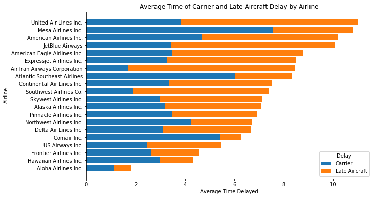

```python
plt.figure(figsize = (10, 6))

carrier_plot_avg = plt.barh(delay_airline_total.index, carrier_davg)
late_plot_avg = plt.barh(delay_airline_total.index, late_davg, left = carrier_davg)

plt.title("Average Time of Carrier and Late Aircraft Delay by Airline")
plt.xlabel("Average Time Delayed")
plt.ylabel("Airline")

plt.legend((carrier_plot_avg, late_plot_avg), ("Carrier", "Late Aircraft"), title = "Delay");
```

From the above plot, four airlines have an average of over 10 minutes delayed (in descending order of total average time): United Air Lines Inc., Mesa Airlines Inc., American Airlines Inc, and JetBlue Airways. Southwest Arilines Co. which previously shown the highest total time delayed does not have such a high average time delayed. Aloha Airlines Inc. has the best record of lowest average time of delays (under 2 minutes) due to carrier and late aircraft arrival.

#### `ArrDelay`, `DepDelay`, and `Year`

**How has the average departure and arrival delay change over the past 20 years (five year intervals between 1988-2008)?**

```python
delay_1988 = [f1988.DepDelay.mean(), f1988.ArrDelay.mean()]
delay_1993 = [f1993.DepDelay.mean(), f1993.ArrDelay.mean()]
delay_1998 = [f1998.DepDelay.mean(), f1998.ArrDelay.mean()]
delay_2003 = [f2003.DepDelay.mean(), f2003.ArrDelay.mean()]
delay_2008 = [f2008.DepDelay.mean(), f2008.ArrDelay.mean()]
```

```python
delays_df = pd.DataFrame([delay_1988, delay_1993, delay_1998, delay_2003, delay_2008],
                        columns = ["DepDelayAvg", "ArrDelayAvg"], index = [1988, 1993, 1998, 2003, 2008])
delays_df
```

|  | DepDelayAvg | ArrDelayAvg |
| --- | --- | --- |
| 1988 | 6.706768 | 6.547350 |
| 1993 | 6.122581 | 5.344062 |
| 1998 | 9.024561 | 7.586968 |
| 2003 | 5.248231 | 3.596694 |
| 2008 | 9.972570 | 8.168452 |

For the following plot, the average for both departure and arrival delays are plotted, without taking into account the outliers.

[figure not shown]

```python
plt.figure(figsize = (10, 6))
plt.bar(x = delays_df.index, height = delays_df.DepDelayAvg, width = 2, color = base_color,
        label = "Departure Delay")
plt.bar(x = delays_df.index + 2, height = delays_df.DepDelayAvg, width = 2, color = sb.color_palette()[1],
       label = "Arrival Delay")
plt.title("Average Departure and Arrival Delays for Five Different Years")
plt.xlabel("Year")
plt.ylabel("Average Delay (in minutes)")
plt.legend(title = "Average Delays")

ax = plt.gca().get_xticks()
plt.xticks(ax - 1.05, ["", 1988, 1993, 1998, 2003, 2008]);
```

If extreme outliers are removed, and say the delays of interest are anywhere between -20 minutes and 120 minutes, the following plot will be created. This removes extreme values, for example in 2008, there were flights up to 40 hours delayed.

```python
delay_1988_outliers = (f1988[(f1988.DepDelay >= -20) & (f1988.DepDelay <= 120)].DepDelay.mean(),
                       f1988[(f1988.ArrDelay >= -20) & (f1988.ArrDelay <= 120)].ArrDelay.mean())
delay_1993_outliers = (f1993[(f1993.DepDelay >= -20) & (f1993.DepDelay <= 120)].DepDelay.mean(),
                       f1993[(f1993.ArrDelay >= -20) & (f1993.ArrDelay <= 120)].ArrDelay.mean())
delay_1998_outliers = (f1998[(f1998.DepDelay >= -20) & (f1998.DepDelay <= 120)].DepDelay.mean(),
                       f1998[(f1998.ArrDelay >= -20) & (f1998.ArrDelay <= 120)].ArrDelay.mean())
delay_2003_outliers = (f2003[(f2003.DepDelay >= -20) & (f2003.DepDelay <= 120)].DepDelay.mean(),
                       f2003[(f2003.ArrDelay >= -20) & (f2003.ArrDelay <= 120)].ArrDelay.mean())
delay_2008_outliers = (f2008[(f2008.DepDelay >= -20) & (f2008.DepDelay <= 120)].DepDelay.mean(),
                       f2008[(f2008.ArrDelay >= -20) & (f2008.ArrDelay <= 120)].ArrDelay.mean())
```

```python
delays_df_outliers = pd.DataFrame([delay_1988_outliers, delay_1993_outliers, delay_1998_outliers,
                                   delay_2003_outliers, delay_2008_outliers],
                                  columns = ["DepDelayAvg", "ArrDelayAvg"], index = [1988, 1993, 1998, 2003, 2008])
delays_df_outliers
```

|  | DepDelayAvg | ArrDelayAvg |
| --- | --- | --- |
| 1988 | 5.657600 | 5.901268 |
| 1993 | 5.159929 | 4.702635 |
| 1998 | 6.694841 | 6.099257 |
| 2003 | 3.546093 | 3.054556 |
| 2008 | 6.294562 | 5.864995 |

[figure not shown]

```python
plt.figure(figsize = (10, 6))
plt.bar(x = delays_df_outliers.index, height = delays_df_outliers.DepDelayAvg, width = 2, color = base_color,
        label = "Departure Delay")
plt.bar(x = delays_df_outliers.index + 2, height = delays_df_outliers.DepDelayAvg, width = 2, color = sb.color_palette()[1],
       label = "Arrival Delay")
plt.title("Average Departure and Arrival Delays for Five Different Years (extreme outliers removed)")
plt.xlabel("Year")
plt.ylabel("Average Delay (in minutes)")
plt.legend(title = "Average Delays")

ax = plt.gca().get_xticks()
plt.xticks(ax - 1.05, ["", 1988, 1993, 1998, 2003, 2008]);
```

By removing outliers, 1998 becomes the year with the highest average delays, followed by 2008. 2003 as from previous plot has the lowest average delays.

#### Number of flights throughout the `Year`

**How has the number of flight departures change with a 7-day moving average over the past 20 years (five year intervals between 1988-2008)?**

First change the name of column `DayofMonth` to `Day` for the DF from 1988-2003.

```python
name_change = {"DayofMonth": "Day"}
f1988_clean.rename(columns = name_change, inplace = True)
f1993_clean.rename(columns = name_change, inplace = True)
f1998_clean.rename(columns = name_change, inplace = True)
f2003_clean.rename(columns = name_change, inplace = True)
f2003_clean.head()
```

[output not shown]

Then create new column as datetime object. Subsequently, the total number of flights can be grouped by day.

```python
f1988_clean["DateTime"] = pd.to_datetime(f1988_clean[["Year", "Month", "Day"]])
f1993_clean["DateTime"] = pd.to_datetime(f1993_clean[["Year", "Month", "Day"]])
f1998_clean["DateTime"] = pd.to_datetime(f1998_clean[["Year", "Month", "Day"]])
f2003_clean["DateTime"] = pd.to_datetime(f2003_clean[["Year", "Month", "Day"]])
f2003_clean.head()
```

|  | Year | Month | Day | ArrDelay | DepDelay | Cancelled | DateTime |
| --- | --- | --- | --- | --- | --- | --- | --- |
| 0 | 2003 | 1 | 29 | -1.0 | -4.0 | False | 2003-01-29 |
| 1 | 2003 | 1 | 30 | -3.0 | -1.0 | False | 2003-01-30 |
| 2 | 2003 | 1 | 31 | 23.0 | 29.0 | False | 2003-01-31 |
| 3 | 2003 | 1 | 1 | -9.0 | -2.0 | False | 2003-01-01 |
| 4 | 2003 | 1 | 2 | 52.0 | 18.0 | False | 2003-01-02 |

```python
flight_1988 = f1988_clean.groupby("DateTime").count()
flight_1993 = f1993_clean.groupby("DateTime").count()
flight_1998 = f1998_clean.groupby("DateTime").count()
flight_2003 = f2003_clean.groupby("DateTime").count()
flight_2008 = f2008_clean.groupby("DateTime").count()
flight_2003.head()
```

| DateTime | Year | Month | Day | ArrDelay | DepDelay | Cancelled |
| --- | --- | --- | --- | --- | --- | --- |
| 2003-01-01 | 16144 | 16144 | 16144 | 15998 | 16012 | 16144 |
| 2003-01-02 | 18528 | 18528 | 18528 | 18249 | 18279 | 18528 |
| 2003-01-03 | 18870 | 18870 | 18870 | 18471 | 18488 | 18870 |
| 2003-01-04 | 16131 | 16131 | 16131 | 15903 | 15919 | 16131 |
| 2003-01-05 | 17642 | 17642 | 17642 | 17371 | 17404 | 17642 |

To plot different days of the year for different years, additional tidiness issues has been addressed as follows.

```python
# 1988 and 2008 were leap years. For simplicity of plots, the leap days will be removed
flight_1988 = flight_1988[flight_1988.index != "1988-02-29"]
flight_2008 = flight_2008[flight_2008.index != "2008-02-29"]
len(flight_1988), len(flight_2008)
```

```
(365, 365)
```

```python
# Calculating 7-day moving average
ma_1988 = flight_1988.Year.rolling(window = 7).mean()
ma_1993 = flight_1993.Year.rolling(window = 7).mean()
ma_1998 = flight_1998.Year.rolling(window = 7).mean()
ma_2003 = flight_2003.Year.rolling(window = 7).mean()
ma_2008 = flight_2008.Year.rolling(window = 7).mean()
```

```python
# Convert to numpy array to allow for plotting of time series of different years on same chart
ma_1988_array = np.array(ma_1988.values)
ma_1993_array = np.array(ma_1993.values)
ma_1998_array = np.array(ma_1998.values)
ma_2003_array = np.array(ma_2003.values)
ma_2008_array = np.array(ma_2008.values)
```

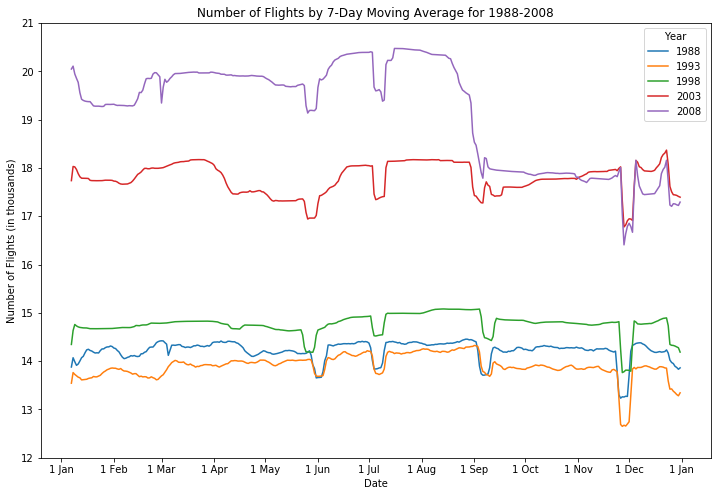

```python
plt.figure(figsize = (12, 8))

x = [i for i in range(1, 366)]

plt.errorbar(x, y = ma_1988_array, label = "1988")
plt.errorbar(x, y = ma_1993_array, label = "1993")
plt.errorbar(x, y = ma_1998_array, label = "1998")
plt.errorbar(x, y = ma_2003_array, label = "2003")
plt.errorbar(x, y = ma_2008_array, label = "2008")

plt.title("Number of Flights by 7-Day Moving Average for 1988-2008")
plt.xlabel("Date")
plt.ylabel("Number of Flights (in thousands)")
ticks30 = np.array([n for n in range (12, 22)])
plt.yticks(ticks30 * 1000, ticks30)
plt.legend(title = "Year");

plt.xticks([1, 32, 60, 91, 121, 152, 182, 213, 244, 274, 305, 335, 366],
           ["1 Jan", "1 Feb", "1 Mar", "1 Apr", "1 May", "1 Jun",
            "1 Jul", "1 Aug", "1 Sep", "1 Oct", "1 Nov", "1 Dec", "1 Jan"]);
```

As shown above, year 1993 has on average the lowest number of flights, followed by 1988 and then 1998. 2003 has the second highest number of flights and 2008 has the highest the number of flights scheduled.

By looking at the all five plots, there are several patterns that are visible. There is a small dip in flights at the end of May to the beginning of June, and at the beginning of July and September. There tends to be a signficant dip at the end of November and beginning of December for all years. In 2008, the number of flights experience a huge fall from around mid-August compared with other years, which is uncharacteristic.

### Analysis and Insights of Multivariate Exploration

Jump to Multivariate Visualisations

Jump to Top of the Page